[figure not shown]

# Linguagem R – estruturação de dados e análise reproduzível

14/11/2017

[Jony Arrais Pinto Junior](http://lattes.cnpq.br/4940428746026448)

## 1 - Conteúdo da Aula 09

1. Conhecendo o shiny;
2. Text;
3. Reactivity.

## 2 - Shiny

Shiny é um novo pacote do RStudio que torna incrivelmente fácil a criação de aplicações web interativas com R.

## 3 - Instalação

Shiny está disponível no CRAN.

```
install.packages("shiny")
```

## 4 - Executando um exemplo

Para entendermos o que o shiny pode nos propiciar, vamos ativar o pacote e executar um exemplo disponível.

```
library(shiny)
runExample("01_hello")
```

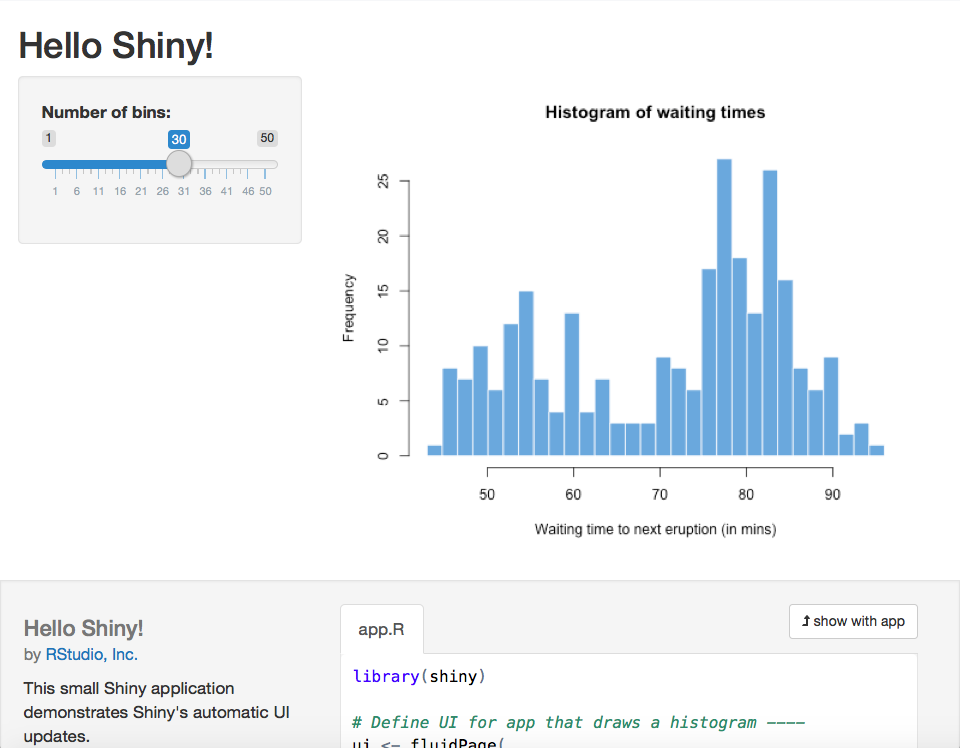

## 4 - Componentes do shiny

Os aplicativos **Shiny** possuem dois componentes: uma **definição de interface do usuário** e um **script de servidor**.

A interface do usuário é definida em um arquivo fonte chamado ui:

```
# Define UI para o app que desenha um histograma ----
ui <- fluidPage(

  # Título do aplicativo ----
  titlePanel("Hello Shiny!"),

  # Layout da barra lateral com definições de entrada e saída ----
  sidebarLayout(

    # Painel da barra lateral para entradas ----
    sidebarPanel(

      # Entrada: controle deslizante para o número de intervalos ----
      sliderInput(inputId = "bins",
                  label = "Number of bins:",
                  min = 1,
                  max = 50,
                  value = 30)

    ),

    # Painel principal para exibir saídas ----
    mainPanel(

      # Output: Histograma ----
      plotOutput(outputId = "distPlot")

    )
  )
)
```

Já o script do servidor é apresentado abaixo:

```
# Defini a lógica do servidor necessária para desenhar um histograma ----
server <- function(input, output) {

  # Histogram of the Old Faithful Geyser Data ----
  # with requested number of bins
  # This expression that generates a histogram is wrapped in a call
  # to renderPlot to indicate that:
  #
  # 1. It is "reactive" and therefore should be automatically
  #    re-executed when inputs (input$bins) change
  # 2. Its output type is a plot
  output$distPlot <- renderPlot({

    x    <- faithful$waiting
    bins <- seq(min(x), max(x), length.out = input$bins + 1)

    hist(x, breaks = bins, col = "#75AADB", border = "white",
         xlab = "Waiting time to next eruption (in mins)",
         main = "Histogram of waiting times")

    })

}
```

Se você dipõe dos dois componentes, basta utilizarmos o comando abaixo para gerar o app:

```
# Criando um aplicativo Shiny ----
shinyApp(ui = ui, server = server)
```

Faça as modificações apropriadas para que o app fique como abaixo:

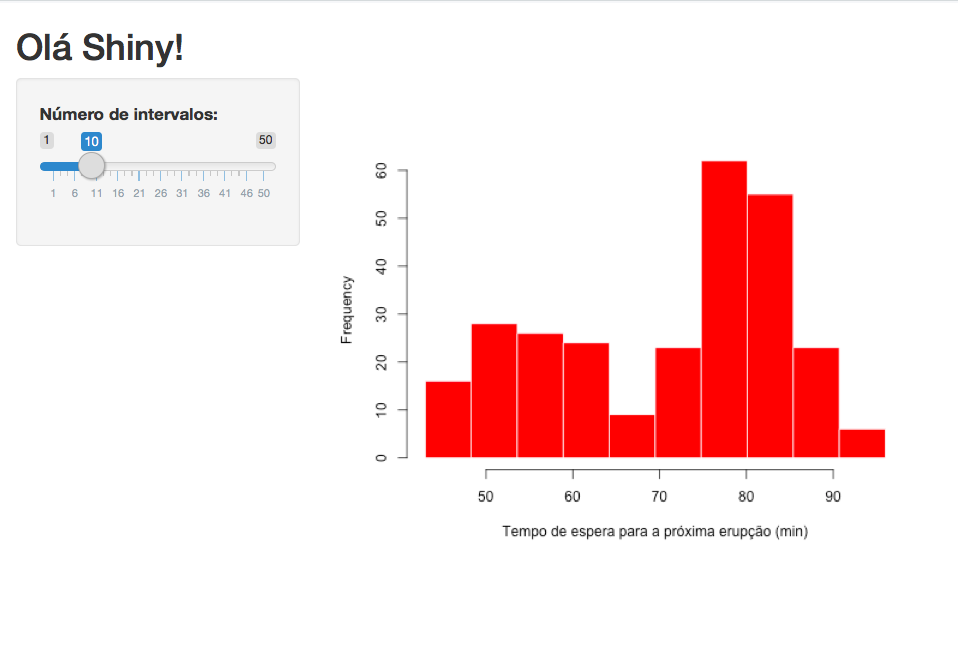

## 5 - Shiny Text

O app shiny text mostra como printar objetos do R diretamente, bem como printar data.frames usando tabelas HTML.

O primeiro exemplo teve uma única entrada numérica especificada usando um controle deslizante e uma única saída de plotagem. Este exemplo possui um pouco mais: duas entradas e dois tipos de saída textual.

Aqui está a definição da interface do usuário para o aplicativo. Observe, em particular, que as funções **sidebarPanel** e **mainPanel** são agora chamadas com dois argumentos (correspondentes às duas entradas e duas saídas exibidas):

O lado do servidor do aplicativo também ficou um pouco mais complicado. Agora criamos:

- Uma **expressão reativa** para retornar o conjunto de dados correspondente à escolha do usuário
- Duas outras expressões de renderização (**renderIrint** e **renderTable**) que retornam os valores **output$summary** and **output$view**.

```
# Define UI for dataset viewer app ----
ui <- fluidPage(

  # App title ----
  titlePanel("Shiny Text"),

  # Sidebar layout with a input and output definitions ----
  sidebarLayout(

    # Sidebar panel for inputs ----
    sidebarPanel(

      # Input: Selector for choosing dataset ----
      selectInput(inputId = "dataset",
                  label = "Escolha sua base de dados:",
                  choices = c("rock", "pressure", "cars")),

      # Input: Numeric entry for number of obs to view ----
      numericInput(inputId = "obs",
                   label = "Numéro de observações para visualizar:",
                   value = 10)
    ),

    # Main panel for displaying outputs ----
    mainPanel(

      # Output: Verbatim text for data summary ----
      verbatimTextOutput("summary"),

      # Output: HTML table with requested number of observations ----
      tableOutput("view")

    )
  )
)

# Define server logic to summarize and view selected dataset ----
server <- function(input, output) {

  # Return the requested dataset ----
  datasetInput <- reactive({
    switch(input$dataset,
           "rock" = rock,
           "pressure" = pressure,
           "cars" = cars)
  })

  # Generate a summary of the dataset ----
  output$summary <- renderPrint({
    dataset <- datasetInput()
    summary(dataset)
  })

  # Show the first "n" observations ----
  output$view <- renderTable({
    head(datasetInput(), n = input$obs)
  })

}

# Create Shiny app ----
shinyApp(ui = ui, server = server)
```

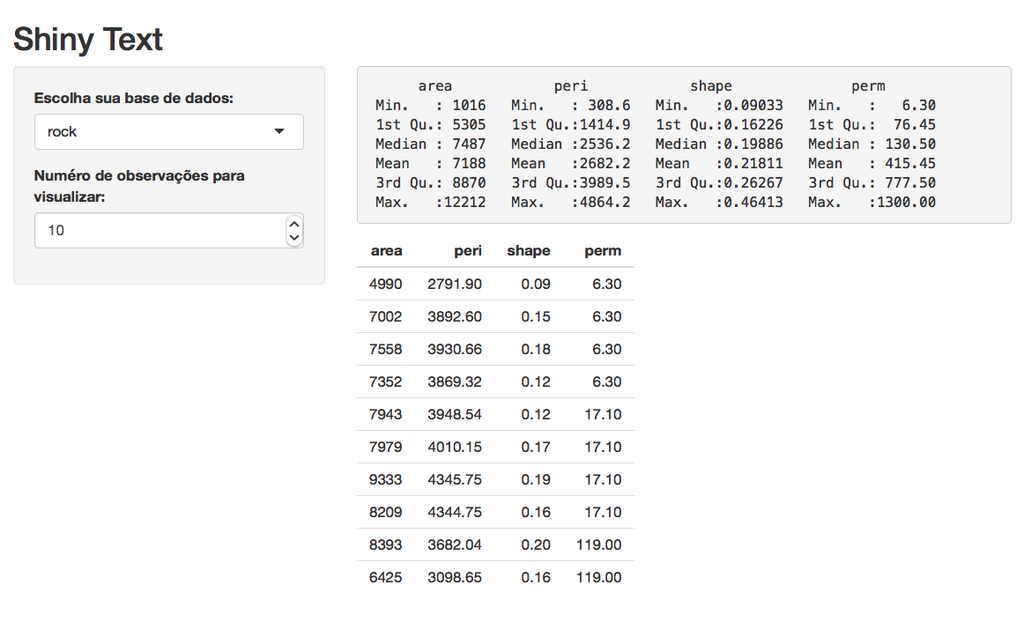

Se ao invés de todas as medidas eu quisesse apresentar somente a média (com duas casas decimais), quais as modificações eu precisaria executar?

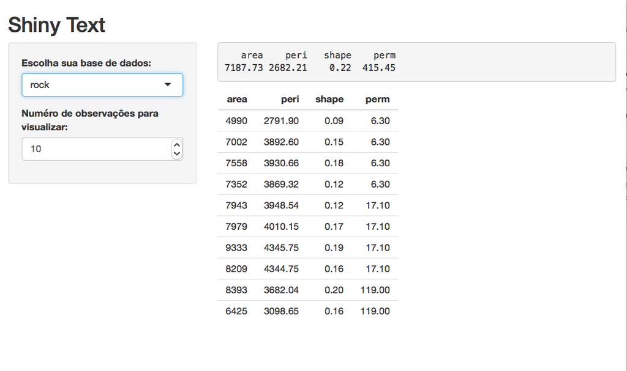

## 6 - Shiny Reactivity

O aplicativo de Reatividade é muito parecido com o Shiny Text, mas envolve muito mais detalhes sobre conceitos de programação reativa.

```
# Define UI for dataset viewer app ----
ui <- fluidPage(

  # App title ----
  titlePanel("Reactivity"),

  # Sidebar layout with input and output definitions ----
  sidebarLayout(

    # Sidebar panel for inputs ----
    sidebarPanel(

      # Input: Text for providing a caption ----
      # Note: Changes made to the caption in the textInput control
      # are updated in the output area immediately as you type
      textInput(inputId = "caption",
                label = "Título:",
                value = "Resumo dos dados"),

      # Input: Selector for choosing dataset ----
      selectInput(inputId = "dataset",
                  label = "Escolha a base de dados:",
                  choices = c("rock", "pressure", "cars")),

      # Input: Numeric entry for number of obs to view ----
      numericInput(inputId = "obs",
                   label = "Número de observações para visualizar:",
                   value = 10)

    ),

    # Main panel for displaying outputs ----
    mainPanel(

      # Output: Formatted text for caption ----
      h3(textOutput("caption", container = span)),

      # Output: Verbatim text for data summary ----
      verbatimTextOutput("summary"),

```

[output cut: 45 more lines]

```
    summary(dataset)
  })

  # Show the first "n" observations ----
  # The output$view depends on both the databaseInput reactive
  # expression and input$obs, so it will be re-executed whenever
  # input$dataset or input$obs is changed
  output$view <- renderTable({
    head(datasetInput(), n = input$obs)
  })

}

# Create Shiny app ----
shinyApp(ui, server)
```

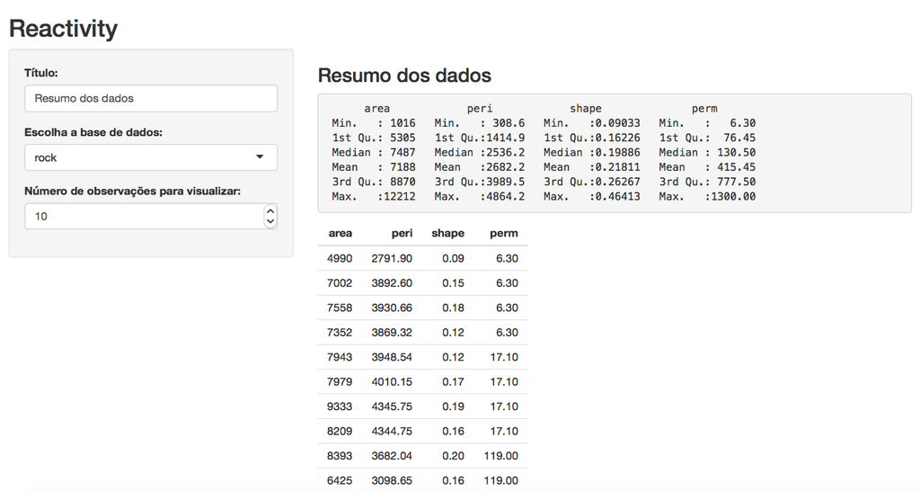

## 7 - Outros exemplos

```
# Define UI for random distribution app ----
ui <- fluidPage(

  # App title ----
  titlePanel("Números aleatórios"),

  # Sidebar layout with input and output definitions ----
  sidebarLayout(

    # Sidebar panel for inputs ----
    sidebarPanel(

      # Input: Select the random distribution type ----
      radioButtons("dist", "Tipo de distribuição:",
                   c("Normal" = "norm",
                     "Uniforme" = "unif",
                     "Log-normal" = "lnorm",
                     "Exponencial" = "exp")),

      # br() element to introduce extra vertical spacing ----
      br(),

      # Input: Slider for the number of observations to generate ----
      sliderInput("n",
                  "Número de observações:",
                  value = 500,
                  min = 100,
                  max = 1000)

    ),

    # Main panel for displaying outputs ----
    mainPanel(

      # Output: Tabset w/ plot, summary, and table ----
      tabsetPanel(type = "tabs",
                  tabPanel("Gráfico", plotOutput("plot")),
                  tabPanel("Resumo", verbatimTextOutput("summary")),
                  tabPanel("Tabela", tableOutput("table"))
      )
```

[output cut: 35 more lines]

```

  # Generate a summary of the data ----
  output$summary <- renderPrint({
    summary(d())
  })

  # Generate an HTML table view of the data ----
  output$table <- renderTable({
    d()
  })

}

# Create Shiny app ----
shinyApp(ui, server)
```

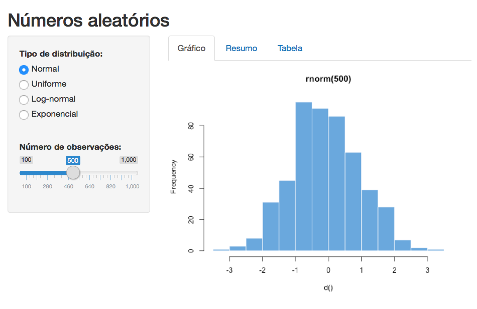

```
# Define UI para o app que desenha um histograma ----
ui <- fluidPage(

  # Título do aplicativo ----
  titlePanel("Hello Shiny!"),

  # Layout da barra lateral com definições de entrada e saída ----
  sidebarLayout(

    # Painel da barra lateral para entradas ----
    sidebarPanel(

      # Entrada: controle deslizante para o número de intervalos ----
      sliderInput(inputId = "bins",
                  label = "Number of bins:",
                  min = 1,
                  max = 50,
                  value = 30)

    ),

    # Painel principal para exibir saídas ----
    mainPanel(

      # Output: Histograma ----
      plotOutput(outputId = "distPlot")

    )
  )
)

# Defini a lógica do servidor necessária para desenhar um histograma ----
server <- function(input, output) {

  # Histogram of the Old Faithful Geyser Data ----
  # with requested number of bins
  # This expression that generates a histogram is wrapped in a call
  # to renderPlot to indicate that:
  #
  # 1. It is "reactive" and therefore should be automatically
  #    re-executed when inputs (input$bins) change
  # 2. Its output type is a plot
  output$distPlot <- renderPlot({

    x    <- faithful$waiting
    bins <- seq(min(x), max(x), length.out = input$bins + 1)

    hist(x, breaks = bins, col = "#75AADB", border = "white",
         xlab = "Waiting time to next eruption (in mins)",
         main = "Histogram of waiting times")

    })

}

# Create Shiny app ----
shinyApp(ui = ui, server = server)
```

[figure not shown]

```
# Define UI for slider demo app ----
ui <- fluidPage(

  pageWithSidebar(
    headerPanel('Cluster k-means'),
    sidebarPanel(
      selectInput('xcol', 'Eixo X', names(iris)),
      selectInput('ycol', 'Eixo Y', names(iris),
                  selected=names(iris)[[2]]),
      numericInput('clusters', 'Número de clusteres', 3,
                   min = 1, max = 9)
    ),
    mainPanel(
      plotOutput('plot1')
    )
  )
)

# Define server logic for slider examples ----
server <- function(input, output, session) {

  # Combine the selected variables into a new data frame
  selectedData <- reactive({
    iris[, c(input$xcol, input$ycol)]
  })

  clusters <- reactive({
    kmeans(selectedData(), input$clusters)
  })

  output$plot1 <- renderPlot({
    palette(c("#E41A1C", "#377EB8", "#4DAF4A", "#984EA3",
              "#FF7F00", "#FFFF33", "#A65628", "#F781BF", "#999999"))

    par(mar = c(5.1, 4.1, 0, 1))
    plot(selectedData(),
         col = clusters()$cluster,
         pch = 20, cex = 3)
    points(clusters()$centers, pch = 4, cex = 4, lwd = 4)
  })

}
# Create Shiny app ----
shinyApp(ui, server)
```

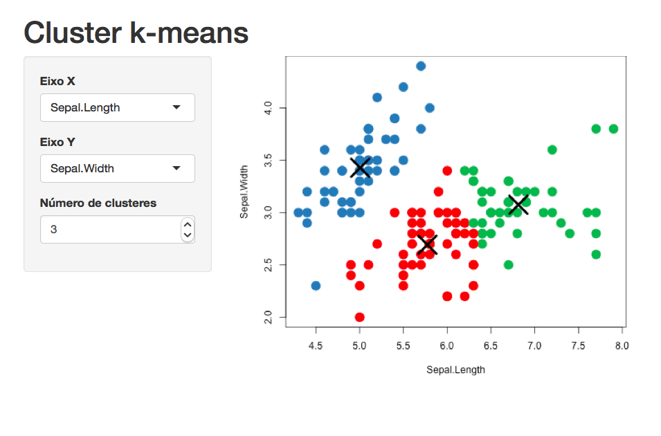

```
library(ggplot2)
library(Cairo)   # For nicer ggplot2 output when deployed on Linux

ui <- fluidPage(
  fluidRow(
    column(width = 4, class = "well",
      h4("Brush and double-click to zoom"),
      plotOutput("plot1", height = 300,
        dblclick = "plot1_dblclick",
        brush = brushOpts(
          id = "plot1_brush",
          resetOnNew = TRUE
        )
      )
    ),
    column(width = 8, class = "well",
      h4("Left plot controls right plot"),
      fluidRow(
        column(width = 6,
          plotOutput("plot2", height = 300,
            brush = brushOpts(
              id = "plot2_brush",
              resetOnNew = TRUE
            )
          )
        ),
        column(width = 6,
          plotOutput("plot3", height = 300)
        )
      )
    )

  )
)

server <- function(input, output) {

  # -------------------------------------------------------------------
  # Single zoomable plot (on left)
  ranges <- reactiveValues(x = NULL, y = NULL)
```

[output cut: 38 more lines]

```
  observe({
    brush <- input$plot2_brush
    if (!is.null(brush)) {
      ranges2$x <- c(brush$xmin, brush$xmax)
      ranges2$y <- c(brush$ymin, brush$ymax)

    } else {
      ranges2$x <- NULL
      ranges2$y <- NULL
    }
  })

}

shinyApp(ui, server)
```

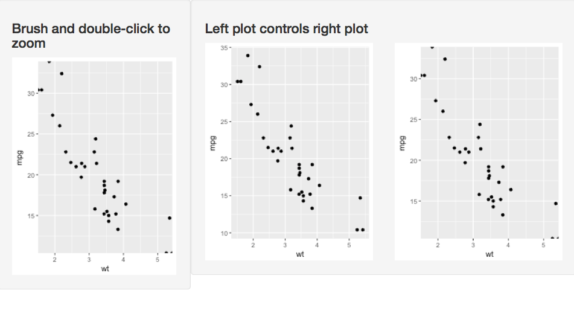